# Risk Factor Analysis

## Outcome Variable

**Outcome Variable:** wasted

## Predictor Variables

**Intervention Variable:** fage

**Adjustment Set:**

- arm
- W_mage
- meducyrs
- feducyrs
- W_mhtcm
- W_mwtkg
- W_mbmi
- W_fhtcm
- single
- brthmon
- delta_W_mage
- delta_meducyrs
- delta_feducyrs
- delta_W_mhtcm
- delta_W_mwtkg
- delta_W_mbmi
- delta_W_fhtcm
- delta_single
- delta_brthmon

## Stratifying Variables

The analysis was stratified on these variable(s):

- agecat
- studyid
- country

## Data Summary

| agecat | studyid | country | fage | wasted | n_cell | n |
| --- | --- | --- | --- | --- | --- | --- |
| Birth | ki0047075b-MAL-ED | BANGLADESH | >=38 | 0 | 54 | 140 |
| Birth | ki0047075b-MAL-ED | BANGLADESH | >=38 | 1 | 11 | 140 |
| Birth | ki0047075b-MAL-ED | BANGLADESH | <32 | 0 | 19 | 140 |
| Birth | ki0047075b-MAL-ED | BANGLADESH | <32 | 1 | 6 | 140 |
| Birth | ki0047075b-MAL-ED | BANGLADESH | [32-38) | 0 | 44 | 140 |
| Birth | ki0047075b-MAL-ED | BANGLADESH | [32-38) | 1 | 6 | 140 |
| Birth | ki0047075b-MAL-ED | BRAZIL | >=38 | 0 | 25 | 65 |
| Birth | ki0047075b-MAL-ED | BRAZIL | >=38 | 1 | 0 | 65 |
| Birth | ki0047075b-MAL-ED | BRAZIL | <32 | 0 | 16 | 65 |
| Birth | ki0047075b-MAL-ED | BRAZIL | <32 | 1 | 0 | 65 |
| Birth | ki0047075b-MAL-ED | BRAZIL | [32-38) | 0 | 23 | 65 |
| Birth | ki0047075b-MAL-ED | BRAZIL | [32-38) | 1 | 1 | 65 |
| Birth | ki0047075b-MAL-ED | INDIA | >=38 | 0 | 24 | 128 |
| Birth | ki0047075b-MAL-ED | INDIA | >=38 | 1 | 2 | 128 |
| Birth | ki0047075b-MAL-ED | INDIA | <32 | 0 | 31 | 128 |
| Birth | ki0047075b-MAL-ED | INDIA | <32 | 1 | 12 | 128 |
| Birth | ki0047075b-MAL-ED | INDIA | [32-38) | 0 | 49 | 128 |
| Birth | ki0047075b-MAL-ED | INDIA | [32-38) | 1 | 10 | 128 |
| Birth | ki0047075b-MAL-ED | NEPAL | >=38 | 0 | 13 | 59 |
| Birth | ki0047075b-MAL-ED | NEPAL | >=38 | 1 | 0 | 59 |
| Birth | ki0047075b-MAL-ED | NEPAL | <32 | 0 | 7 | 59 |
| Birth | ki0047075b-MAL-ED | NEPAL | <32 | 1 | 2 | 59 |
| Birth | ki0047075b-MAL-ED | NEPAL | [32-38) | 0 | 33 | 59 |
| Birth | ki0047075b-MAL-ED | NEPAL | [32-38) | 1 | 4 | 59 |
| Birth | ki0047075b-MAL-ED | PERU | >=38 | 0 | 27 | 78 |
| Birth | ki0047075b-MAL-ED | PERU | >=38 | 1 | 0 | 78 |
| Birth | ki0047075b-MAL-ED | PERU | <32 | 0 | 24 | 78 |
| Birth | ki0047075b-MAL-ED | PERU | <32 | 1 | 2 | 78 |
| Birth | ki0047075b-MAL-ED | PERU | [32-38) | 0 | 25 | 78 |
| Birth | ki0047075b-MAL-ED | PERU | [32-38) | 1 | 0 | 78 |

[output cut: 180 more lines]

The following strata were considered:

- agecat: 24 months, studyid: ki0047075b-MAL-ED, country: BANGLADESH
- agecat: 24 months, studyid: ki0047075b-MAL-ED, country: BRAZIL
- agecat: 24 months, studyid: ki0047075b-MAL-ED, country: INDIA
- agecat: 24 months, studyid: ki0047075b-MAL-ED, country: NEPAL
- agecat: 24 months, studyid: ki0047075b-MAL-ED, country: PERU
- agecat: 24 months, studyid: ki0047075b-MAL-ED, country: SOUTH AFRICA
- agecat: 24 months, studyid: ki0047075b-MAL-ED, country: TANZANIA, UNITED REPUBLIC OF
- agecat: 24 months, studyid: ki1119695-PROBIT, country: BELARUS
- agecat: 24 months, studyid: ki1135781-COHORTS, country: GUATEMALA
- agecat: 24 months, studyid: ki1135781-COHORTS, country: PHILIPPINES
- agecat: 24 months, studyid: ki1148112-LCNI-5, country: MALAWI
- agecat: 6 months, studyid: ki0047075b-MAL-ED, country: BANGLADESH
- agecat: 6 months, studyid: ki0047075b-MAL-ED, country: BRAZIL
- agecat: 6 months, studyid: ki0047075b-MAL-ED, country: INDIA
- agecat: 6 months, studyid: ki0047075b-MAL-ED, country: NEPAL
- agecat: 6 months, studyid: ki0047075b-MAL-ED, country: PERU
- agecat: 6 months, studyid: ki0047075b-MAL-ED, country: SOUTH AFRICA
- agecat: 6 months, studyid: ki0047075b-MAL-ED, country: TANZANIA, UNITED REPUBLIC OF
- agecat: 6 months, studyid: ki1000304b-SAS-CompFeed, country: INDIA
- agecat: 6 months, studyid: ki1000304b-SAS-FoodSuppl, country: INDIA
- agecat: 6 months, studyid: ki1119695-PROBIT, country: BELARUS
- agecat: 6 months, studyid: ki1135781-COHORTS, country: GUATEMALA
- agecat: 6 months, studyid: ki1135781-COHORTS, country: PHILIPPINES
- agecat: 6 months, studyid: ki1148112-LCNI-5, country: MALAWI
- agecat: Birth, studyid: ki0047075b-MAL-ED, country: BANGLADESH
- agecat: Birth, studyid: ki0047075b-MAL-ED, country: BRAZIL
- agecat: Birth, studyid: ki0047075b-MAL-ED, country: INDIA
- agecat: Birth, studyid: ki0047075b-MAL-ED, country: NEPAL
- agecat: Birth, studyid: ki0047075b-MAL-ED, country: PERU
- agecat: Birth, studyid: ki0047075b-MAL-ED, country: SOUTH AFRICA
- agecat: Birth, studyid: ki0047075b-MAL-ED, country: TANZANIA, UNITED REPUBLIC OF
- agecat: Birth, studyid: ki1000304b-SAS-CompFeed, country: INDIA
- agecat: Birth, studyid: ki1119695-PROBIT, country: BELARUS
- agecat: Birth, studyid: ki1135781-COHORTS, country: GUATEMALA
- agecat: Birth, studyid: ki1135781-COHORTS, country: PHILIPPINES

### Dropped Strata

Some strata were dropped due to rare outcomes:

- agecat: Birth, studyid: ki0047075b-MAL-ED, country: BRAZIL
- agecat: Birth, studyid: ki0047075b-MAL-ED, country: INDIA
- agecat: Birth, studyid: ki0047075b-MAL-ED, country: NEPAL
- agecat: Birth, studyid: ki0047075b-MAL-ED, country: PERU
- agecat: Birth, studyid: ki0047075b-MAL-ED, country: SOUTH AFRICA
- agecat: Birth, studyid: ki0047075b-MAL-ED, country: TANZANIA, UNITED REPUBLIC OF
- agecat: Birth, studyid: ki1000304b-SAS-CompFeed, country: INDIA
- agecat: 6 months, studyid: ki0047075b-MAL-ED, country: BANGLADESH
- agecat: 6 months, studyid: ki0047075b-MAL-ED, country: BRAZIL
- agecat: 6 months, studyid: ki0047075b-MAL-ED, country: INDIA
- agecat: 6 months, studyid: ki0047075b-MAL-ED, country: NEPAL
- agecat: 6 months, studyid: ki0047075b-MAL-ED, country: PERU
- agecat: 6 months, studyid: ki0047075b-MAL-ED, country: SOUTH AFRICA
- agecat: 6 months, studyid: ki0047075b-MAL-ED, country: TANZANIA, UNITED REPUBLIC OF
- agecat: 6 months, studyid: ki1148112-LCNI-5, country: MALAWI
- agecat: 24 months, studyid: ki0047075b-MAL-ED, country: BANGLADESH
- agecat: 24 months, studyid: ki0047075b-MAL-ED, country: BRAZIL
- agecat: 24 months, studyid: ki0047075b-MAL-ED, country: INDIA
- agecat: 24 months, studyid: ki0047075b-MAL-ED, country: NEPAL
- agecat: 24 months, studyid: ki0047075b-MAL-ED, country: PERU
- agecat: 24 months, studyid: ki0047075b-MAL-ED, country: SOUTH AFRICA
- agecat: 24 months, studyid: ki0047075b-MAL-ED, country: TANZANIA, UNITED REPUBLIC OF
- agecat: 24 months, studyid: ki1119695-PROBIT, country: BELARUS
- agecat: 24 months, studyid: ki1148112-LCNI-5, country: MALAWI

## Methods Detail

We’re interested in the causal parameters $E[Y_a]$ for all values of $a \in \mathcal{A}$. These parameters represent the mean outcome if, possibly contrary to fact, we intervened to set all units to have $A=a$. Under the randomization and positivity assumptions, these are identified by the statistical parameters $\psi_a=E_W[E_{Y|A,W}(Y|A=a,W)]$. In addition, we’re interested in the mean of $Y$, $E[Y]$ under no intervention (the observed mean). We will estimate these parameters by using SuperLearner to fit the relevant likelihood factors – $E_{Y|A,W}(Y|A=a,W)$ and $p(A=a|W)$, and then updating our likelihood fit using a joint TMLE.

For unadjusted analyses ($W=\{\}$), initial likelihoods were estimated using Lrnr_glm to estimate the simple $E(Y|A)$ and Lrnr_mean to estimate $p(A)$. For adjusted analyses, a small library containing Lrnr_glmnet, Lrnr_xgboost, and Lrnr_mean was used.

Having estimated these parameters, we will then use the delta method to estimate relative risks and attributable risks relative to a prespecified baseline level of $A$.

# Results Detail

## Results Plots

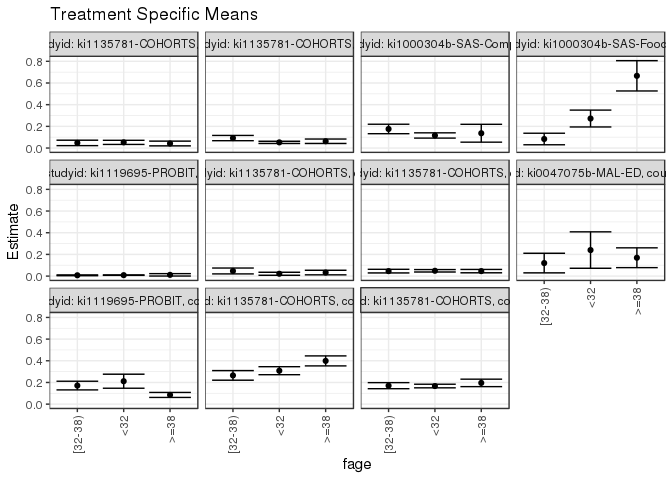

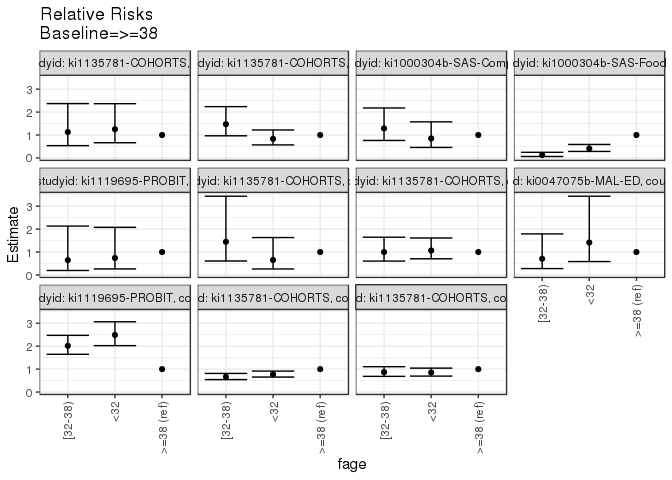

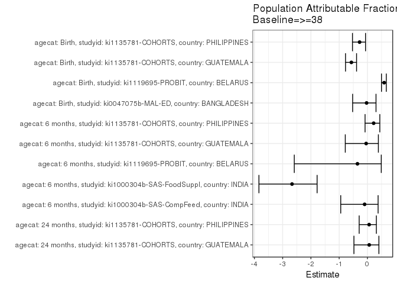

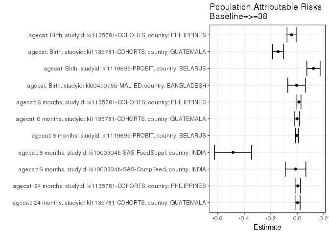

## Results Table

### Parameter: TSM

| agecat | studyid | country | intervention_level | baseline_level | estimate | ci_lower | ci_upper |
| --- | --- | --- | --- | --- | --- | --- | --- |
| Birth | ki0047075b-MAL-ED | BANGLADESH | >=38 | NA | 0.1692308 | 0.0777504 | 0.2607111 |
| Birth | ki0047075b-MAL-ED | BANGLADESH | <32 | NA | 0.2400000 | 0.0719854 | 0.4080146 |
| Birth | ki0047075b-MAL-ED | BANGLADESH | [32-38) | NA | 0.1200000 | 0.0296035 | 0.2103965 |
| Birth | ki1119695-PROBIT | BELARUS | >=38 | NA | 0.0848819 | 0.0617079 | 0.1080559 |
| Birth | ki1119695-PROBIT | BELARUS | <32 | NA | 0.2113878 | 0.1465728 | 0.2762027 |
| Birth | ki1119695-PROBIT | BELARUS | [32-38) | NA | 0.1712146 | 0.1312927 | 0.2111366 |
| Birth | ki1135781-COHORTS | GUATEMALA | >=38 | NA | 0.3989181 | 0.3529295 | 0.4449068 |
| Birth | ki1135781-COHORTS | GUATEMALA | <32 | NA | 0.3083164 | 0.2713722 | 0.3452606 |
| Birth | ki1135781-COHORTS | GUATEMALA | [32-38) | NA | 0.2650827 | 0.2208768 | 0.3092887 |
| Birth | ki1135781-COHORTS | PHILIPPINES | >=38 | NA | 0.1959210 | 0.1613985 | 0.2304436 |
| Birth | ki1135781-COHORTS | PHILIPPINES | <32 | NA | 0.1669126 | 0.1503910 | 0.1834342 |
| Birth | ki1135781-COHORTS | PHILIPPINES | [32-38) | NA | 0.1703358 | 0.1422290 | 0.1984425 |
| 6 months | ki1000304b-SAS-CompFeed | INDIA | >=38 | NA | 0.1363636 | 0.0538801 | 0.2188472 |
| 6 months | ki1000304b-SAS-CompFeed | INDIA | <32 | NA | 0.1158645 | 0.0916826 | 0.1400465 |
| 6 months | ki1000304b-SAS-CompFeed | INDIA | [32-38) | NA | 0.1757576 | 0.1320926 | 0.2194226 |
| 6 months | ki1000304b-SAS-FoodSuppl | INDIA | >=38 | NA | 0.6661622 | 0.5263328 | 0.8059916 |
| 6 months | ki1000304b-SAS-FoodSuppl | INDIA | <32 | NA | 0.2720776 | 0.1943224 | 0.3498327 |
| 6 months | ki1000304b-SAS-FoodSuppl | INDIA | [32-38) | NA | 0.0832719 | 0.0302335 | 0.1363103 |
| 6 months | ki1119695-PROBIT | BELARUS | >=38 | NA | 0.0114123 | 0.0003147 | 0.0225098 |
| 6 months | ki1119695-PROBIT | BELARUS | <32 | NA | 0.0084607 | 0.0064263 | 0.0104950 |
| 6 months | ki1119695-PROBIT | BELARUS | [32-38) | NA | 0.0073785 | 0.0038513 | 0.0109056 |
| 6 months | ki1135781-COHORTS | GUATEMALA | >=38 | NA | 0.0326087 | 0.0116437 | 0.0535737 |
| 6 months | ki1135781-COHORTS | GUATEMALA | <32 | NA | 0.0213777 | 0.0075538 | 0.0352015 |
| 6 months | ki1135781-COHORTS | GUATEMALA | [32-38) | NA | 0.0472103 | 0.0199632 | 0.0744574 |
| 6 months | ki1135781-COHORTS | PHILIPPINES | >=38 | NA | 0.0458153 | 0.0301768 | 0.0614539 |
| 6 months | ki1135781-COHORTS | PHILIPPINES | <32 | NA | 0.0489181 | 0.0375689 | 0.0602674 |
| 6 months | ki1135781-COHORTS | PHILIPPINES | [32-38) | NA | 0.0457461 | 0.0289559 | 0.0625363 |
| 24 months | ki1135781-COHORTS | GUATEMALA | >=38 | NA | 0.0417613 | 0.0199895 | 0.0635330 |
| 24 months | ki1135781-COHORTS | GUATEMALA | <32 | NA | 0.0523382 | 0.0333107 | 0.0713656 |
| 24 months | ki1135781-COHORTS | GUATEMALA | [32-38) | NA | 0.0471526 | 0.0221731 | 0.0721320 |
| 24 months | ki1135781-COHORTS | PHILIPPINES | >=38 | NA | 0.0625005 | 0.0420618 | 0.0829392 |
| 24 months | ki1135781-COHORTS | PHILIPPINES | <32 | NA | 0.0521298 | 0.0419788 | 0.0622809 |
| 24 months | ki1135781-COHORTS | PHILIPPINES | [32-38) | NA | 0.0918834 | 0.0676471 | 0.1161197 |

### Parameter: E(Y)

| agecat | studyid | country | intervention_level | baseline_level | estimate | ci_lower | ci_upper |
| --- | --- | --- | --- | --- | --- | --- | --- |
| Birth | ki0047075b-MAL-ED | BANGLADESH | NA | NA | 0.1642857 | 0.1026873 | 0.2258841 |
| Birth | ki1119695-PROBIT | BELARUS | NA | NA | 0.2079052 | 0.1425355 | 0.2732749 |
| Birth | ki1135781-COHORTS | GUATEMALA | NA | NA | 0.2544218 | 0.2229136 | 0.2859300 |
| Birth | ki1135781-COHORTS | PHILIPPINES | NA | NA | 0.1533786 | 0.1400217 | 0.1667355 |
| 6 months | ki1000304b-SAS-CompFeed | INDIA | NA | NA | 0.1239669 | 0.0988748 | 0.1490591 |
| 6 months | ki1000304b-SAS-FoodSuppl | INDIA | NA | NA | 0.1815789 | 0.1427684 | 0.2203895 |
| 6 months | ki1119695-PROBIT | BELARUS | NA | NA | 0.0084327 | 0.0066853 | 0.0101801 |
| 6 months | ki1135781-COHORTS | GUATEMALA | NA | NA | 0.0311828 | 0.0200060 | 0.0423596 |
| 6 months | ki1135781-COHORTS | PHILIPPINES | NA | NA | 0.0587338 | 0.0497323 | 0.0677353 |
| 24 months | ki1135781-COHORTS | GUATEMALA | NA | NA | 0.0445736 | 0.0319770 | 0.0571703 |
| 24 months | ki1135781-COHORTS | PHILIPPINES | NA | NA | 0.0664983 | 0.0564781 | 0.0765186 |

### Parameter: RR

| agecat | studyid | country | intervention_level | baseline_level | estimate | ci_lower | ci_upper |
| --- | --- | --- | --- | --- | --- | --- | --- |
| Birth | ki0047075b-MAL-ED | BANGLADESH | >=38 | >=38 | 1.0000000 | 1.0000000 | 1.0000000 |
| Birth | ki0047075b-MAL-ED | BANGLADESH | <32 | >=38 | 1.4181818 | 0.5856109 | 3.4344303 |
| Birth | ki0047075b-MAL-ED | BANGLADESH | [32-38) | >=38 | 0.7090909 | 0.2805621 | 1.7921519 |
| Birth | ki1119695-PROBIT | BELARUS | >=38 | >=38 | 1.0000000 | 1.0000000 | 1.0000000 |
| Birth | ki1119695-PROBIT | BELARUS | <32 | >=38 | 2.4903745 | 2.0241898 | 3.0639246 |
| Birth | ki1119695-PROBIT | BELARUS | [32-38) | >=38 | 2.0170918 | 1.6464042 | 2.4712398 |
| Birth | ki1135781-COHORTS | GUATEMALA | >=38 | >=38 | 1.0000000 | 1.0000000 | 1.0000000 |
| Birth | ki1135781-COHORTS | GUATEMALA | <32 | >=38 | 0.7728814 | 0.6536062 | 0.9139229 |
| Birth | ki1135781-COHORTS | GUATEMALA | [32-38) | >=38 | 0.6645041 | 0.5432625 | 0.8128036 |
| Birth | ki1135781-COHORTS | PHILIPPINES | >=38 | >=38 | 1.0000000 | 1.0000000 | 1.0000000 |
| Birth | ki1135781-COHORTS | PHILIPPINES | <32 | >=38 | 0.8519380 | 0.6960771 | 1.0426982 |
| Birth | ki1135781-COHORTS | PHILIPPINES | [32-38) | >=38 | 0.8694103 | 0.6832620 | 1.1062729 |
| 6 months | ki1000304b-SAS-CompFeed | INDIA | >=38 | >=38 | 1.0000000 | 1.0000000 | 1.0000000 |
| 6 months | ki1000304b-SAS-CompFeed | INDIA | <32 | >=38 | 0.8496732 | 0.4582271 | 1.5755168 |
| 6 months | ki1000304b-SAS-CompFeed | INDIA | [32-38) | >=38 | 1.2888889 | 0.7620445 | 2.1799704 |
| 6 months | ki1000304b-SAS-FoodSuppl | INDIA | >=38 | >=38 | 1.0000000 | 1.0000000 | 1.0000000 |
| 6 months | ki1000304b-SAS-FoodSuppl | INDIA | <32 | >=38 | 0.4084254 | 0.2838378 | 0.5876995 |
| 6 months | ki1000304b-SAS-FoodSuppl | INDIA | [32-38) | >=38 | 0.1250024 | 0.0634651 | 0.2462078 |
| 6 months | ki1119695-PROBIT | BELARUS | >=38 | >=38 | 1.0000000 | 1.0000000 | 1.0000000 |
| 6 months | ki1119695-PROBIT | BELARUS | <32 | >=38 | 0.7413648 | 0.2644592 | 2.0782853 |
| 6 months | ki1119695-PROBIT | BELARUS | [32-38) | >=38 | 0.6465386 | 0.1961174 | 2.1314386 |
| 6 months | ki1135781-COHORTS | GUATEMALA | >=38 | >=38 | 1.0000000 | 1.0000000 | 1.0000000 |
| 6 months | ki1135781-COHORTS | GUATEMALA | <32 | >=38 | 0.6555819 | 0.2633944 | 1.6317271 |
| 6 months | ki1135781-COHORTS | GUATEMALA | [32-38) | >=38 | 1.4477825 | 0.6102174 | 3.4349634 |
| 6 months | ki1135781-COHORTS | PHILIPPINES | >=38 | >=38 | 1.0000000 | 1.0000000 | 1.0000000 |
| 6 months | ki1135781-COHORTS | PHILIPPINES | <32 | >=38 | 1.0677244 | 0.7063995 | 1.6138678 |
| 6 months | ki1135781-COHORTS | PHILIPPINES | [32-38) | >=38 | 0.9984892 | 0.6053904 | 1.6468392 |
| 24 months | ki1135781-COHORTS | GUATEMALA | >=38 | >=38 | 1.0000000 | 1.0000000 | 1.0000000 |
| 24 months | ki1135781-COHORTS | GUATEMALA | <32 | >=38 | 1.2532714 | 0.6640317 | 2.3653826 |
| 24 months | ki1135781-COHORTS | GUATEMALA | [32-38) | >=38 | 1.1290989 | 0.5378768 | 2.3701790 |
| 24 months | ki1135781-COHORTS | PHILIPPINES | >=38 | >=38 | 1.0000000 | 1.0000000 | 1.0000000 |
| 24 months | ki1135781-COHORTS | PHILIPPINES | <32 | >=38 | 0.8340711 | 0.5699359 | 1.2206191 |
| 24 months | ki1135781-COHORTS | PHILIPPINES | [32-38) | >=38 | 1.4701235 | 0.9658396 | 2.2377039 |

### Parameter: PAR

| agecat | studyid | country | intervention_level | baseline_level | estimate | ci_lower | ci_upper |
| --- | --- | --- | --- | --- | --- | --- | --- |
| Birth | ki0047075b-MAL-ED | BANGLADESH | >=38 | NA | -0.0049451 | -0.0712182 | 0.0613281 |
| Birth | ki1119695-PROBIT | BELARUS | >=38 | NA | 0.1230233 | 0.0728927 | 0.1731539 |
| Birth | ki1135781-COHORTS | GUATEMALA | >=38 | NA | -0.1444964 | -0.1865742 | -0.1024186 |
| Birth | ki1135781-COHORTS | PHILIPPINES | >=38 | NA | -0.0425424 | -0.0769532 | -0.0081316 |
| 6 months | ki1000304b-SAS-CompFeed | INDIA | >=38 | NA | -0.0123967 | -0.0901578 | 0.0653644 |
| 6 months | ki1000304b-SAS-FoodSuppl | INDIA | >=38 | NA | -0.4845833 | -0.6241581 | -0.3450085 |
| 6 months | ki1119695-PROBIT | BELARUS | >=38 | NA | -0.0029796 | -0.0140524 | 0.0080932 |
| 6 months | ki1135781-COHORTS | GUATEMALA | >=38 | NA | -0.0014259 | -0.0188492 | 0.0159974 |
| 6 months | ki1135781-COHORTS | PHILIPPINES | >=38 | NA | 0.0129185 | -0.0025598 | 0.0283967 |
| 24 months | ki1135781-COHORTS | GUATEMALA | >=38 | NA | 0.0028124 | -0.0162784 | 0.0219032 |
| 24 months | ki1135781-COHORTS | PHILIPPINES | >=38 | NA | 0.0039978 | -0.0159989 | 0.0239946 |

### Parameter: PAF

| agecat | studyid | country | intervention_level | baseline_level | estimate | ci_lower | ci_upper |
| --- | --- | --- | --- | --- | --- | --- | --- |
| Birth | ki0047075b-MAL-ED | BANGLADESH | >=38 | NA | -0.0301003 | -0.5237568 | 0.3036246 |
| Birth | ki1119695-PROBIT | BELARUS | >=38 | NA | 0.5917277 | 0.4973736 | 0.6683695 |
| Birth | ki1135781-COHORTS | GUATEMALA | >=38 | NA | -0.5679403 | -0.7754776 | -0.3846621 |
| Birth | ki1135781-COHORTS | PHILIPPINES | >=38 | NA | -0.2773686 | -0.5294540 | -0.0668321 |
| 6 months | ki1000304b-SAS-CompFeed | INDIA | >=38 | NA | -0.1000000 | -0.9449871 | 0.3778879 |
| 6 months | ki1000304b-SAS-FoodSuppl | INDIA | >=38 | NA | -2.6687195 | -3.8394261 | -1.7812188 |
| 6 months | ki1119695-PROBIT | BELARUS | >=38 | NA | -0.3533345 | -2.5888223 | 0.4896615 |
| 6 months | ki1135781-COHORTS | GUATEMALA | >=38 | NA | -0.0457271 | -0.7839164 | 0.3869975 |
| 6 months | ki1135781-COHORTS | PHILIPPINES | >=38 | NA | 0.2199496 | -0.0836019 | 0.4384666 |
| 24 months | ki1135781-COHORTS | GUATEMALA | >=38 | NA | 0.0630954 | -0.4775960 | 0.4059335 |
| 24 months | ki1135781-COHORTS | PHILIPPINES | >=38 | NA | 0.0601195 | -0.2918793 | 0.3162091 |